# The Model Isn’t Always the Answer

AI, statistics, and the judgment behind good decisions

Cooper Maughan

## What is generative AI?

Generative AI learns patterns from data using statistical frameworks and uses them to produce new content.

- Text models generate text.
- Image models generate images.
- Audio models generate sound.

**Plausible output is not necessarily true output.**

## More complex doesn’t always mean better

**The goal is to perform well on data the model has never seen.**

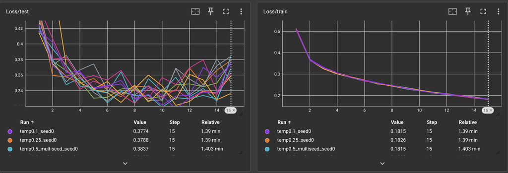

*Training loss keeps improving. Test loss turns back up.*

## When using models, always check your assumptions

In statistics, we make many assumptions about the distribution of data, the type of test we can run, or even the errors.

**Sports example: the hot hand**

- **Assumption:** each shot is independent of the one before it.
- **1985 study:** found no evidence of streak shooting. It became known as a “fallacy.”
- **Later research:** found the original method was biased, and that small hot-hand effects may exist.

> “All models are wrong, but some are useful.” — George Box

**The question isn’t whether the assumptions are perfect. It’s whether they’re good enough for the decision.**

## Garbage in, garbage out

A model can only work with the information and assumptions it receives.

- Biased or incomplete data can create biased results.
- Poorly chosen outcomes can answer the wrong question.
- A model can perform well on paper and fail in practice.

**Before asking whether the model works, ask what it was built to do.**

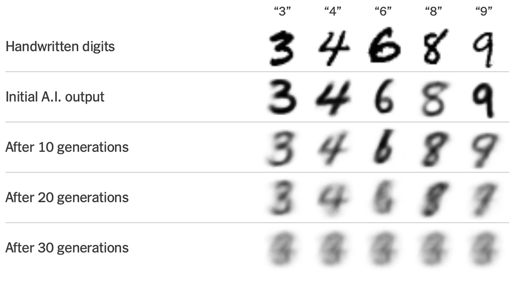

NYT reporting using the MNIST digit set

[Diffusion Article Examples](https://arxiv.org/html/2311.12202v2)

## Accurate doesn’t always mean ethical

**Target’s pregnancy-prediction example**

A retailer used purchasing patterns to infer that some customers might be pregnant.

- Potential benefit: more relevant marketing.
- Potential harm: sensitive inferences and unexpected exposure.

**Just because we can predict something doesn’t mean we should use it.**

[figure not shown]

[figure not shown]

*Sources: Forbes, The New York Times*

## Simpson’s paradox: Berkeley admissions, 1973

**Did Berkeley admit men at a higher rate than women?**

**All six departments combined**

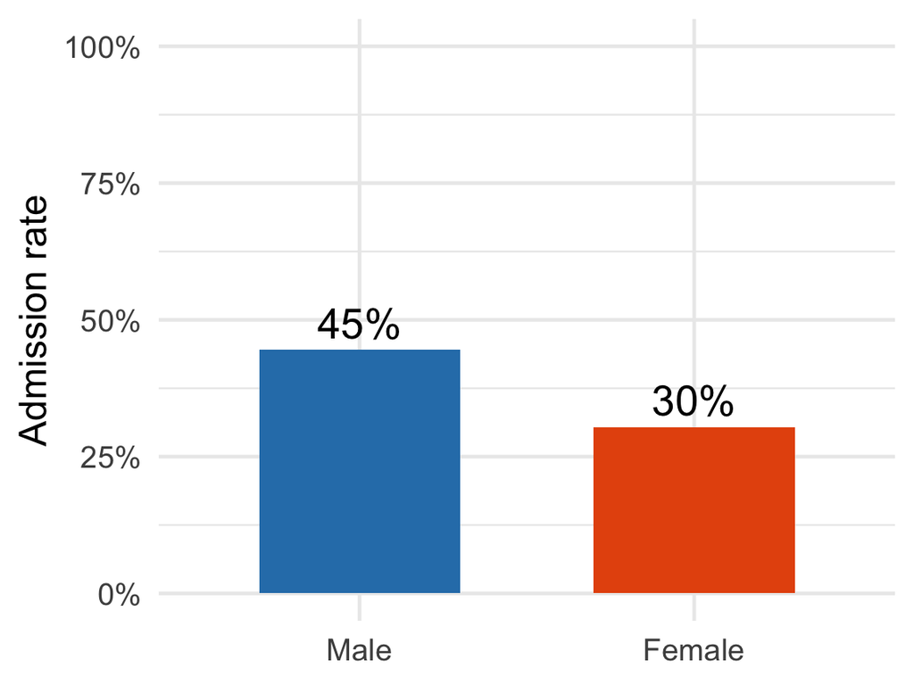

**Within each department**

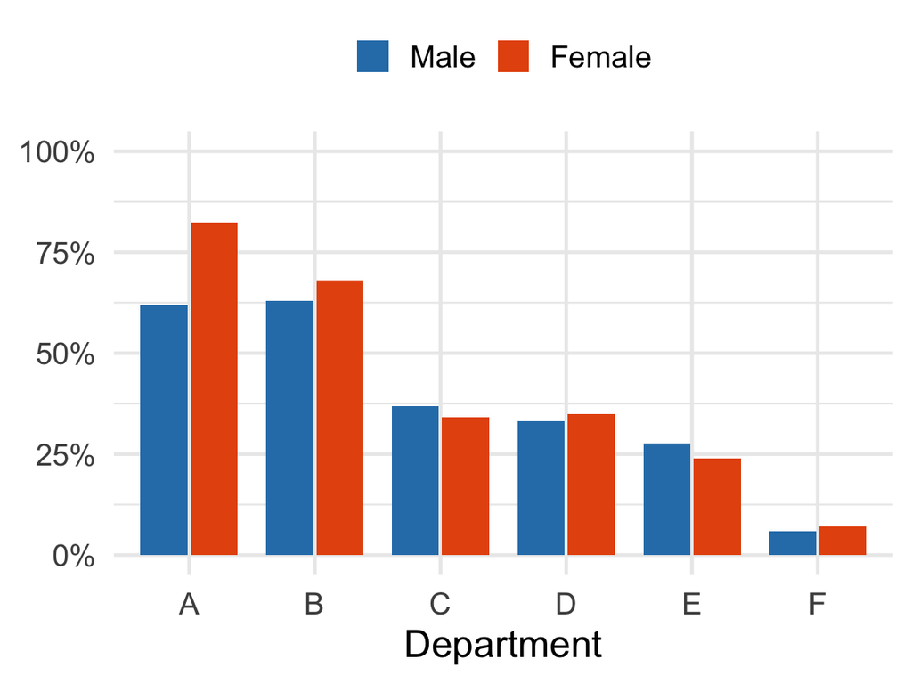

**Women applied mostly to the most competitive departments. The combined number hid that.**

## Simpson’s paradox: does space help LeBron?

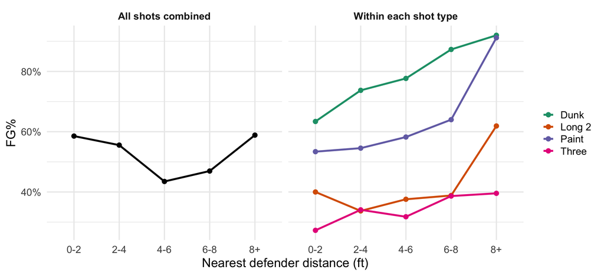

## The model is only part of the advantage

**Data + domain knowledge + validation**

My experience:

[figure not shown]

[figure not shown]

[figure not shown]

## What happens when everyone has the model?

When everyone can access similar tools, access alone stops being a lasting advantage.

**The advantage shifts toward:**

- Better data
- Better questions
- Better evaluation
- Better implementation
- Better judgment

## “Do Your Job”

**A model can assist with the task. It cannot take responsibility for the outcome.**

[figure not shown]

Image sourced from the NFL

## Good, better, best

|  | Strength | Blind spot | Where we saw it |
| --- | --- | --- | --- |
| **Good:** Gut feeling | Context, spotting what doesn’t make sense | Inconsistent, biased, doesn’t scale | Knowing defenders sag off shooters |
| **Better:** Model alone | Consistent, scales, finds patterns | Only knows what it’s given | Simpson’s paradox, Target |
| **Best:** Model + judgment | The model finds patterns, the person checks assumptions | Takes more effort | The Olympic project |

**Use the model to find patterns. Use judgment to decide whether to believe them.**